# Estudio variabilidad estructural proteica

30/01/2016

## Conjuntos de proteinas

### Conjunto teorico

190 mutantes de 1kbt (60 sitios) simuladas con el modelo mutacional LFENM con ANM *R0* = 12 y *Fmax* = 2 (solo para LFENM). Para determinar que sitios mutar, se alineo 1kbt con cada una de las proteinas del conjunto, se obtuvieron los indices de los sitios alineados pero mutados y se simularon 10 mutantes por cada par de proteinas, obteniendose un total de 190 mutantes. Luego, para el analisis, se tomaron como alineados los sitios alineados de 1kbt para cada par de proteinas.

### Conjunto experimental

19 proteinas de la familia de snakesToxin. Las proteinas tienen un promedio de identidad secuencial de 45%. El core del alineamiento de la familia es de 47 sitios.

La caracterizacion del conjunto experimental se muestra a continuacion:

```
##    pdbid nsites naligned identity       MSD
## 1   2crt     60       60 88.33333  8.572226
## 2   2cdx     60       60 85.00000 12.541595
## 3  1cdta     60       60 78.33333  7.626335
## 4  1tgxa     60       60 71.66667  9.079807
## 5  1kxia     62       60 61.66667  9.914270
## 6   1tfs     60       53 41.50943 16.565111
## 7   1drs     59       54 31.48148 19.432519
## 8   1txb     73       57 35.08772 14.186942
## 9   2ctx     71       56 33.92857 11.031610
## 10  1ntn     72       57 33.33333 10.724320
## 11  1lsi     66       56 32.14286 13.091012
## 12 2abxa     74       59 33.89831 13.795044
## 13 2nbta     66       59 28.81356 21.714295
## 14 1nean     61       55 38.18182 12.693952
## 15  1nor     61       55 40.00000  9.632213
## 16  1cod     62       56 32.14286 10.082238
## 17  1nxb     62       56 32.14286 11.162583
## 18  1ntx     60       54 37.03704 10.254098
## 19  1fas     61       55 27.27273 12.741706
```

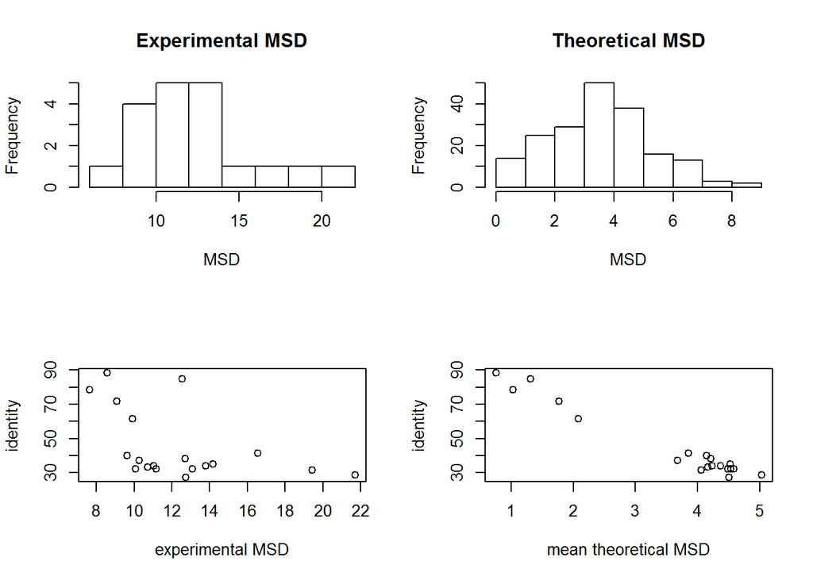

## Comparaciones

### RHO y AUC

Las distribuciones de *auc* y *rho* para cada conjunto se muestran a continuacion (azul= teorico, rojo = experimental)

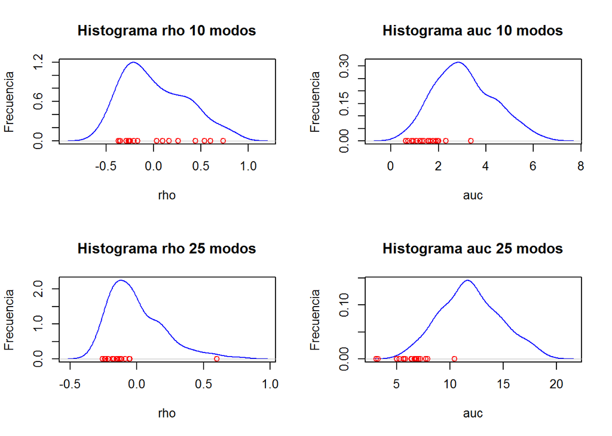

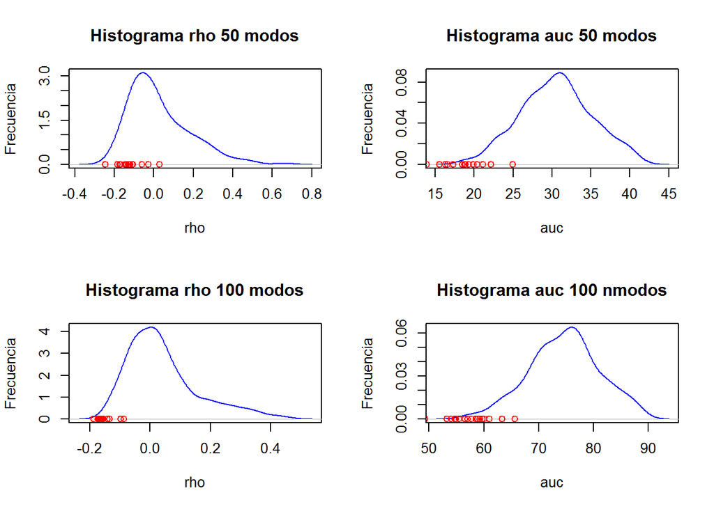

## Pn y Qn

Las distribuciones de *Pn* y *Qn* de los conjuntos son las siguientes:

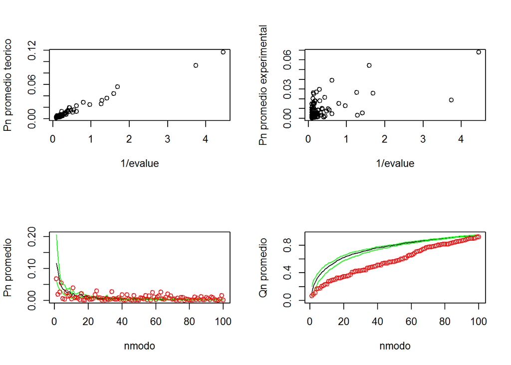

Negro: Teorico Rojo: Experimental Verdes: Cuartiles 0.05 y 0.95 de 10 grupos de 19 mutantes teoricas.